# Ford GoBike System Data analysis Presentation

## by Saad Alrazoq

## Investigation Overview

#### In this investigation, I wanted to take a look around the dataset and find interesting information

#### my main foucs in this presentation was to compare the gender and the age and the time duration or time spent using the bikes by the users, and who used it the most was it

## Dataset Overview

#### in this dataset we have a 16 different features, 183,412 different trips and one of them was dropped because of age

#### and used the dataset to find some patterns that could help the company to discover more information about their customers and subscribers.

# Subscribers and customers percentage

#### In the following section we found a graph that gives us a clear describtion of the difference between the subscribers and the customers

#### where we have 163,544 subscribers which is 89% of the users

#### and we have 19,868 customers and it's 11% of the users

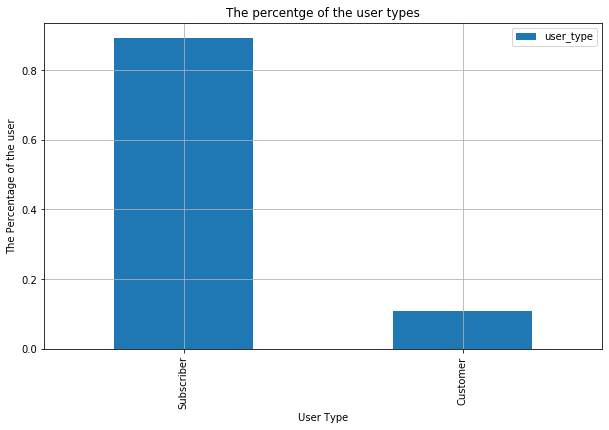

```python
df['user_type'].value_counts(normalize=True).plot(kind='bar',figsize=(10,6))
plt.title('The percentge of the user types')
plt.xlabel('User Type')
plt.ylabel('The Percentage of the user')
plt.legend() ## if needed
plt.grid();
```

# Who uses the bikes the longest time?

#### In the next graph we can notice something, although we have only 11% customers but they are the ones who uses the bikes the longest time, and they have higher time duration spent more than the subscribers

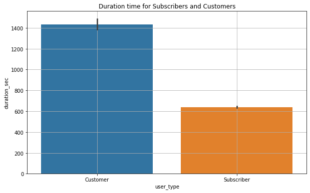

```python
# creating a chart using seaborn library to answer this question
plt.figure(figsize=(10,6))
sb.barplot(x='user_type',y='duration_sec',data=df)
plt.title('Duration time for Subscribers and Customers')
plt.grid()
plt.show()
```

# who uses the bike most? male or female or other?

#### In this question I found what are the gender percentage, and in the following pie chart we found who uses the bike the most out of the 3 genders we have:

#### 1- we can notice that is 75% of the users are male and they were = 130,651 male users

#### 2- also 23% of the users are female users and with the number = 40,844

#### 3- lastly 2% of the users are other gender and they are = 3652 users

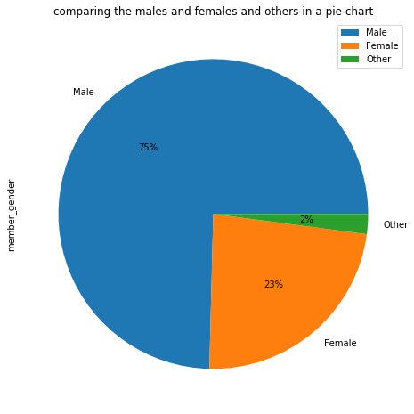

```python
plt.figure(figsize=(9,9))
df['member_gender'].value_counts(normalize=True).plot(kind='pie',figsize=(10,8), autopct='%1.0f%%')
plt.title('comparing the males and females and others in a pie chart')
plt.legend();
```

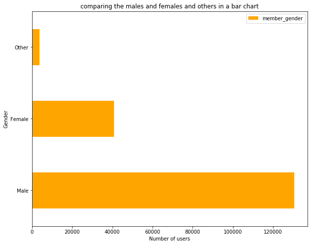

```python
df['member_gender'].value_counts(normalize=False).plot(kind='barh',figsize=(10,8),color='orange')
plt.title('comparing the males and females and others in a bar chart')
plt.xlabel('Number of users')
plt.ylabel('Gender')
plt.legend();
```

# The Duration Time vs The Age

#### from the following visualization, what we can notice that the people who are aged from 25 to 35, they spend a lot of time using the bike with nearly 40,000 seconds

#### but in general we can notice most of them are from 20 to 45 but specificlly from 25 to 35

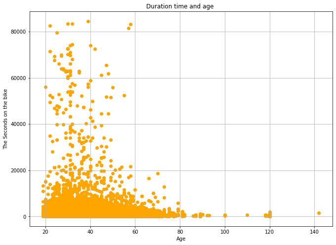

```python
df['Age']= (2020 - df['member_birth_year'])
plt.figure(figsize=(11,8))
plt.scatter( df['Age'],df['duration_sec'],color='orange')
plt.title('Duration time and age ')
plt.grid()
plt.xlabel('Age')
plt.ylabel('The Seconds on the bike')
plt.show()
```

# Comparing The Age and Time duration with Gender

#### We can see from the following graph that:

#### That is the male who spends most of his time on the bike and we can clearly see that from the graph

#### Also it makes sense why male are the most because they are 75% of the users and it might be related to this graph

#### Also most of the females time spent are in range between 0 to 20,000 seconds

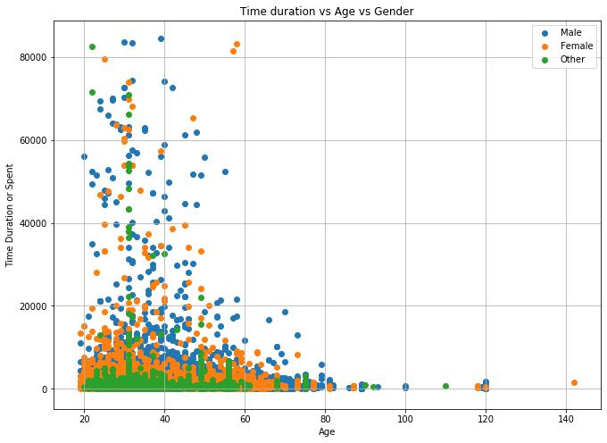

```python
plt.figure(figsize=(11,8))
for gender, s in gender_s:
    df_g=df[df['member_gender']== gender]
    plt.scatter((df_g['Age']),df_g['duration_sec'])
plt.title('Time duration vs Age vs Gender')
plt.xlabel('Age')
plt.ylabel('Time Duration or Spent')
plt.grid()
plt.legend(['Male','Female','Other']);
```